# Chapter 8 Fitting parametric regression models

```r
library(survival)
```

```r
knitr::include_graphics("8_3.PNG")
```

[output not shown]

```r
NA
```

### Required data

The first thing we will do is clean the data load the data

```r
### DataSet

voltages <- read.csv("voltagesT.csv", header=T, sep =";")
head(voltages)
```

|  | V30KV | V32KV | V34KV | V36KV |
| --- | --- | --- | --- | --- |
| 1 | 7.74 | 0.27 | 0.19 | 0.35 |
| 2 | 17.05 | 0.40 | 0.78 | 0.59 |
| 3 | 20.46 | 0.69 | 0.96 | 0.96 |
| 4 | 21.02 | 0.79 | 1.31 | 0.99 |
| 5 | 22.66 | 2.75 | 2.78 | 1.69 |
| 6 | 43.40 | 3.91 | 3.16 | 1.97 |

```r
NA
```

### Data adjustment to eliminate NA values

Now we will adjust the data in independent sensors to facilitate their manipulation.

```r
V30KV <- voltages$V30KV[1:11]
V32KV <- voltages$V32KV[1:15]
V34KV <- voltages$V34KV
V36KV <- voltages$V36KV[1:15]
```

## Diagnostic tests

### Diagnostic 1.

Calculating plotting position for the 4 covariates

```r
### Plotting positions Failure 30KV

i <- seq(1:length(V30KV))
p30 <- 1 - ((i-0.5)/length(i))

### Plotting positions at_test 32KV

i <- seq(1:length(V32KV))
p32 <- 1 - ((i-0.5)/length(i))

### Plotting positions Voltage 34KV

i <- seq(1:length(V34KV))
p34 <- 1 - ((i-0.5)/length(i))

### Plotting positions levels 36KV

i <- seq(1:length(V36KV))
p36 <- 1 - ((i-0.5)/length(i))
```

### Diagnostic 1 graph

For the accelerated models we must calculate the empirical survival function, will show location shifted versions of the baseline survival function when an accelerated lifetimes model is appropriate.

```r
### Plotting the data

plot(log(V32KV),p32,col="red", pch = 19 , ylab= "Plotting position S(t)", xlab="Log (Faliure)",xlim=c(-2,6),ylim=c(0,1), main= "Empirical Survival Function for Diagnostic 1")
points(log(V34KV),p34,col="green", pch = 19)
```

```r
points(log(V30KV),p30,col="blue", pch = 19)
points(log(V36KV),p36,col="orange", pch = 19)
```

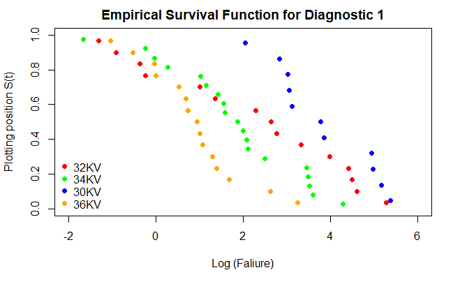

```r
legend("bottomleft", legend=c("32KV", "34KV", "30KV", "36KV"), col = c("red","green","blue","orange"), pch = 19, bty = "n")
```

### Diagnostic 2

By means of the standard deviation, a stabilization is given to the constant variance as proposed by the loglinear model.

```r
SD32 <- sd(log(V32KV))
SD34 <- sd(log(V34KV))
SD30 <- sd(log(V30KV))
SD36 <- sd(log(V36KV))

cbind(SD32, SD34, SD30, SD36)
```

```
         SD32     SD34     SD30     SD36
[1,] 2.188146 1.525211 1.124394 1.109901
```

### Diagnostic 3 graph

Verifying the plots of the proportional hazards, it can be seen that these data fit a straight line under the Weibull model, as proposed in the exercise, Although it could also fit a log-normal distribution.

```r
### Plotting the data

par(mfrow=c(1,3))

plot(log(V32KV),log(-1*log(p32)),col="red", pch = 19 , ylab= "Log log Plotting position", xlab="Log(Faliures)", xlim=c(-2,6), ylim= c(-4,2), main = "Diagnostic 3 Weibull")
points(log(V34KV),log(-1*log(p34)),col="green", pch = 19)
```

```r
points(log(V30KV),log(-1*log(p30)),col="blue", pch = 19)
points(log(V36KV),log(-1*log(p36)),col="orange", pch = 19)
```

```r
legend("topleft", legend=c("32KV", "34KV", "30KV", "36KV"), col = c("red","green","blue","orange"), pch = 19, bty = "n")

plot(log(V32KV),-1*log(p32),col="red", pch = 19 , ylab= "-log Plotting position", xlab="Log(Faliures)", xlim=c(-2,6), ylim= c(0,5), main = "Diagnostic 3 exponential")
```

```r
points(log(V34KV),-1*log(p34),col="green", pch = 19)
points(log(V30KV),-1*log(p30),col="blue", pch = 19)
```

```r
points(log(V36KV),-1*log(p36),col="orange", pch = 19)
legend("topleft", legend=c("32KV", "34KV", "30KV", "36KV"), col = c("red","green","blue","orange"), pch = 19, bty = "n")
```

```r
plot(log(V32KV),qnorm(p32),col="red", pch = 19 , ylab= "LognormalS(t)", xlab="Log(Faliures)", xlim=c(-2,6), ylim= c(-2.5,2), main = "Diagnostic 3 Lognormal")
points(log(V34KV),qnorm(p34),col="green", pch = 19)
```

```r
points(log(V30KV),qnorm(p30),col="blue", pch = 19)
points(log(V36KV),qnorm(p36),col="orange", pch = 19)
```

[output not shown]

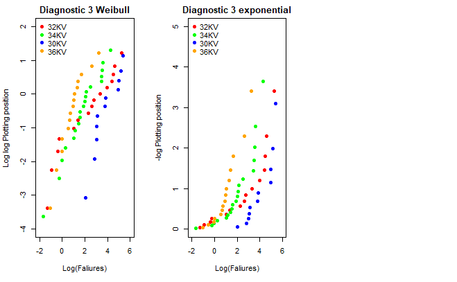

```r
legend("bottomleft", legend=c("32KV", "34KV", "30KV", "36KV"), col = c("red","green","blue","orange"), pch = 19, bty = "n")
```

```r
knitr::include_graphics("8_31.PNG")
```

[output not shown]

```r
NA
```

Next, we will compare the survival function with the Kaplan-Meier estimator model proposed by the task.

### Applying KM estimator

```r
### Kaplan Meier models for the different voltages

km.model32 <- survfit(Surv(V32KV,rep(1,15))~1)
km.model34 <- survfit(Surv(V34KV,rep(1,19))~1)
km.model30 <- survfit(Surv(V30KV,rep(1,11))~1)
km.model36 <- survfit(Surv(V36KV,rep(1,15))~1)
```

Survival and times are taken for each model such that:

```r
### Survival estimators and times for all the different voltages

survEst32 <- km.model32$surv
survTime32 <- km.model32$time

survEst34 <- km.model34$surv
survTime34 <- km.model34$time

survEst30 <- km.model30$surv
survTime30 <- km.model30$time

survEst36 <- km.model36$surv
survTime36 <- km.model36$time
```

### Model fitting

With the above values we fit each model for each covariate:

```r
### Fitting the models

logLogSurvEst32 <- log(-log(survEst32[-15]))
logSurvTime32 <- log(survTime32[-15])
result.lm32 <- lm(logLogSurvEst32 ~ logSurvTime32)

logLogSurvEst34 <- log(-log(survEst34[-19]))
logSurvTime34 <- log(survTime34[-19])
result.lm34 <- lm(logLogSurvEst34 ~ logSurvTime34)

logLogSurvEst30 <- log(-log(survEst30[-11]))
logSurvTime30 <- log(survTime30[-11])
result.lm30 <- lm(logLogSurvEst30 ~ logSurvTime30)

logLogSurvEst36 <- log(-log(survEst36[-15]))
logSurvTime36 <- log(survTime36[-15])
result.lm36 <- lm(logLogSurvEst36 ~ logSurvTime36)
```

### Weibull model fitting graph

Finally fitting the model for all the covariates we can see how the line through them fits almost all the points and with a minimum distance between them and the regression line, so that we can fit the Weibull model as proposed in the exercise to these data.

```r
par(mfrow=c(2,2))

plot(logLogSurvEst32 ~ logSurvTime32, pch=16, xlab="log(Faliure)", sub="32KV",ylab="log(-log(S(t))")
abline(result.lm32, col ="red")
```

```r
plot(logLogSurvEst34 ~ logSurvTime34, pch=16, xlab="log(Faliure)", sub="34KV",ylab="log(-log(S(t))")
abline(result.lm34, col ="green")
```

```r
plot(logLogSurvEst30 ~ logSurvTime30, pch=16, xlab="log(Faliure)", sub="30KV",ylab="log(-log(S(t))")
abline(result.lm30, col ="blue")
```

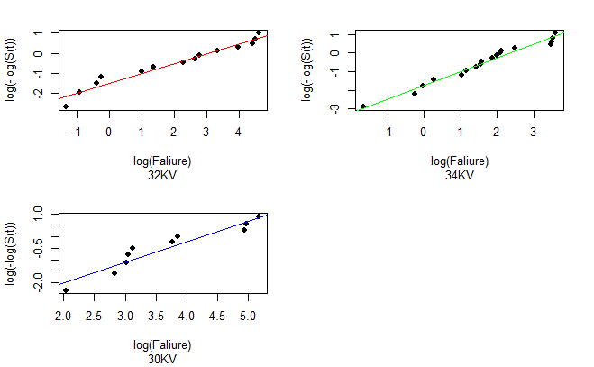

```r
plot(logLogSurvEst36 ~ logSurvTime36, pch=16, xlab="log(Faliure)", sub="36KV",ylab="log(-log(S(t))")
abline(result.lm36, col ="orange")
```

[output not shown]

```r
knitr::include_graphics("8_5.PNG")
```

[output not shown]

```r
NA
```

### Required data

The first thing we will do is clean the data load the data

```r
swt <- read.csv("switches.csv", header=T, sep =";")
head(swt)
```

|  | time | A | B | Group |
| --- | --- | --- | --- | --- |
| 1 | 1.151 | 0 | 1 | B |
| 2 | 1.170 | 0 | 1 | B |
| 3 | 1.248 | 0 | 1 | B |
| 4 | 1.331 | 0 | 1 | B |
| 5 | 1.381 | 0 | 1 | B |
| 6 | 1.499 | 1 | 0 | A |

```r
NA
```

```r
knitr::include_graphics("8_51.PNG")
```

[output not shown]

```r
NA
```

The data were adjusted to independent vectors in order to work better with them, an auxiliary variable has been generated to separate both groups of switches.

```r
GA <- subset(swt, Group == "A")
GB <- subset(swt, Group == "B")
```

### Plotting position Calculations

```r
j <- seq(1,length(GA$time))
pA <- 1 - ((j-0.5)/length(GA$time))

j <- seq(1,length(GB$time))
pB <- 1 - ((j-0.5)/length(GB$time))

inv_phiA <- qnorm(pA)
inv_phiB <- qnorm(pB)
```

### Diagnostic 1 graph

For the accelerated models we must calculate the empirical survival function, will show location shifted versions of the baseline survival function when an accelerated lifetimes model is appropriate.

```r
plot(log(GA$time),pA, main="S(t) Life Times of Mechanical Devices log-linear Model", ylab="S(t)", xlab="Log(Millions of cycles to faliure)", col ="red",pch = 19)
points(log(GB$time), pB, col ="blue", pch = 19)
```

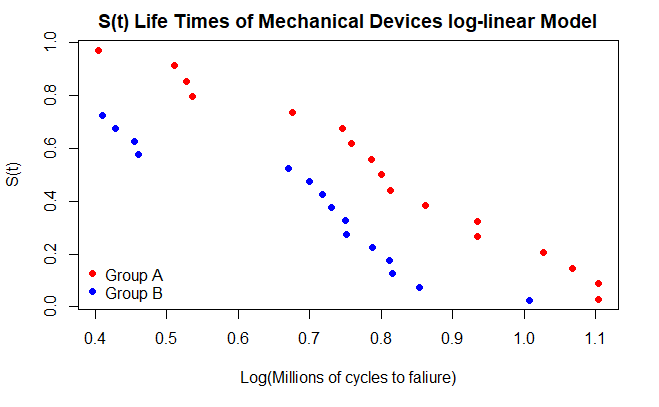

```r
legend("bottomleft", legend=c("Group A", "Group B"), col = c("red","blue"), pch = 19, bty = "n")
```

### Diagnostic 3 graph

Data are projected to find a better model to fit the data

```r
par(mfrow=c(1,3))

plot(log(GA$time), -log(pA), pch=16, xlab="log(Faliure)", sub="Exponencial",ylab="-log(S(t))", col ="red")
points(log(GB$time), -log(pB),pch=16, col="blue")
```

```r
plot(log(GA$time), log(-log(pA)), pch=16, xlab="log(Faliure)", sub="Weibull",ylab="-log(S(t))", col ="red")
points(log(GB$time), log(-log(pB)),pch=16, col="blue")
```

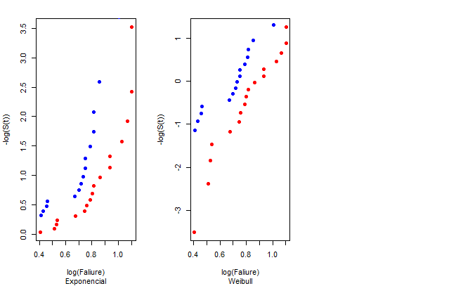

```r
plot(log(GA$time), inv_phiA, pch=16, xlab="log(Faliure)", sub="LogNormal",ylab= expression(Phi^-1 * (S(t))), col ="red")
points(log(GB$time), inv_phiB,pch=16, col="blue")
```

[output not shown]

### Regression calculation

```r
reg_weibullA<-survreg(Surv(GA$time, GA$A)~1, dist='weibull')

reg_weibullB<-survreg(Surv(GB$time, GB$B)~1, dist='weibull')
```

### Extraction of residuals

We extract the residuals to visualize the differences between the generated model and the actual model value of S(t).

```r
resid.devianceA <- residuals(reg_weibullA, type="deviance")
resid.devianceB <- residuals(reg_weibullB, type="deviance")
```

### Visualization of residuals

The residuals are extracted and the quartiles are calculated. As requested in the assignment

```r
par(mfrow=c(1,2))
boxplot(resid.devianceA, col ="red")
title("Deviance residuals\nversus Group A", cex.main = 0.7, xlab ="Group A")
```

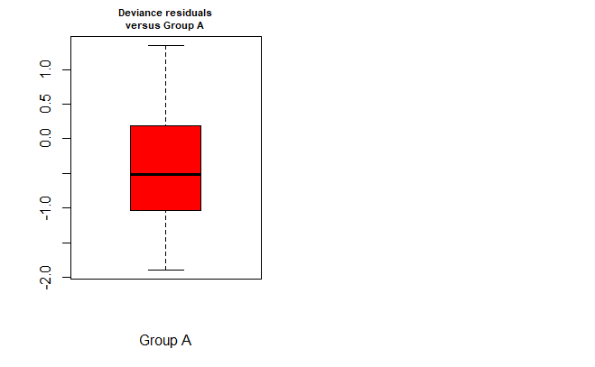

```r
boxplot(resid.devianceB, col ="blue")
title("Deviance residuals\nversus Group B", cex.main = 0.7, xlab ="Group B")
```

[output not shown]

```r
knitr::include_graphics("814.PNG")
```

[output not shown]

```r
NA
```

```r
par(mfrow=c(1,3))

### weibull
plot(logLogSurvEst32 ~ logSurvTime32, pch=16, xlab="log(Faliure)", sub="32KV",ylab="log(-log(S(t))", col ="red")
abline(result.lm32, col ="red")
```

```r
points(logLogSurvEst34 ~ logSurvTime34, pch=16, xlab="log(Faliure)", sub="34KV",ylab="log(-log(S(t))", col ="green")
abline(result.lm34, col ="green")
```

```r
points(logLogSurvEst30 ~ logSurvTime30, pch=16, xlab="log(Faliure)", sub="30KV",ylab="log(-log(S(t))", col ="blue")
abline(result.lm30, col ="blue")
```

```r
points(logLogSurvEst36 ~ logSurvTime36, pch=16, xlab="log(Faliure)", sub="36KV",ylab="log(-log(S(t))",col ="orange")
abline(result.lm36, col ="orange")
```

```r
### weibull
plot(logLogSurvEst32 ~ logSurvTime32, pch=16, xlab="log(Faliure)", sub="32KV",ylab="log(-log(S(t))", col ="red")
abline(result.lm32, col ="red")
```

```r
points(logLogSurvEst34 ~ logSurvTime34, pch=16, xlab="log(Faliure)", sub="34KV",ylab="log(-log(S(t))", col ="green")
abline(result.lm34, col ="green")
```

```r
points(logLogSurvEst30 ~ logSurvTime30, pch=16, xlab="log(Faliure)", sub="30KV",ylab="log(-log(S(t))", col ="blue")
abline(result.lm30, col ="blue")
```

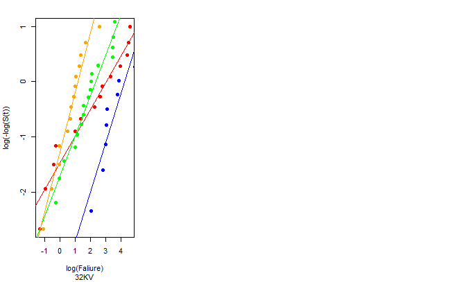

```r
points(logLogSurvEst36 ~ logSurvTime36, pch=16, xlab="log(Faliure)", sub="36KV",ylab="log(-log(S(t))",col ="orange")
abline(result.lm36, col ="orange")
```

[output not shown]

```r
### Plotting the data

par(mfrow=c(1,2))

plot(log(V32KV),log(-1*log(p32)),col="red", pch = 19 , ylab= "Log log Plotting position", xlab="Log(Faliures)", xlim=c(-2,6), ylim= c(-4,2), main = "Diagnostic 3 Weibull")
abline(result.lm32, col ="red")
```

```r
points(log(V34KV),log(-1*log(p34)),col="green", pch = 19)
abline(result.lm34, col ="green")
```

```r
points(log(V30KV),log(-1*log(p30)),col="blue", pch = 19)
abline(result.lm30, col ="blue")
```

```r
points(log(V36KV),log(-1*log(p36)),col="orange", pch = 19)
abline(result.lm36, col ="orange")
```

```r
legend("topleft", legend=c("32KV", "34KV", "30KV", "36KV"), col = c("red","green","blue","orange"), pch = 19, bty = "n")

plot(log(V32KV),qnorm(p32),col="red", pch = 19 , ylab= "LognormalS(t)", xlab="Log(Faliures)", xlim=c(-2,6), ylim= c(-2.5,2), main = "Diagnostic 3 Lognormal")
```

```r
abline(lm(log(V32KV)~qnorm(p32)), col ="red")

points(log(V34KV),qnorm(p34),col="green", pch = 19)
```

```r
points(log(V30KV),qnorm(p30),col="blue", pch = 19)
points(log(V36KV),qnorm(p36),col="orange", pch = 19)
```

[output not shown]

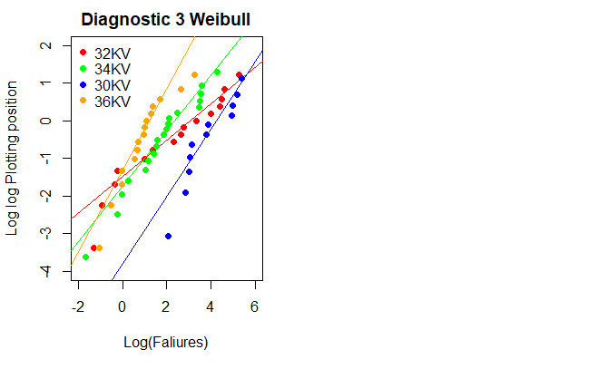

```r
legend("bottomleft", legend=c("32KV", "34KV", "30KV", "36KV"), col = c("red","green","blue","orange"), pch = 19, bty = "n")
```

```r
ploting.rl <- lm(log(-1*log(p32))~log(V32KV))
plot(log(survTime32),log(-1*log(survEst32)),col="red", pch = 19 , ylab= "Log log Plotting position", xlab="Log(Faliures)", xlim=c(-2,6), ylim= c(-4,2), main = "Diagnostic 3 Weibull")
abline(result.lm32,col="red")
```

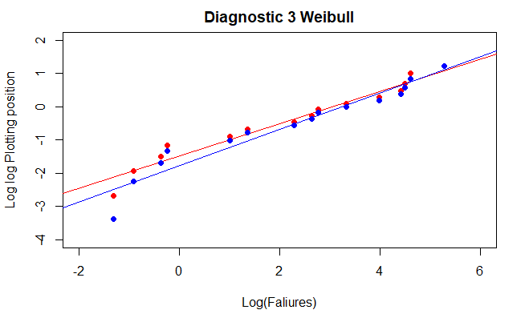

```r
points(log(V32KV),log(-1*log(p32)),col="blue", pch = 19)
abline(ploting.rl, col ="blue")
```